# Waterfowl - LTEM - Yellow Point Bog Ecological Reserve

Published

2023-02-23

# 1 Summary of Waterfowl LTEM protocol

## 1.1 Basic protocol

As taken from the protocol document:

> “Establish observation points at enough sites to provide views of the entire survey area. …

> Choose a date after which migrants are mostly gone. Count on 3 separate occasions during a 2-3 week period and keep > highest count.”

The data collected under this protocol at each survey consists of the following variables:

- Species. The species of waterfowl counted.
- Sex. The sex of the species.
- Count. The number of birds of this species and sex. Choose a date after which migrants are mostly gone

## 1.2 Cautions about the protocol.

### 1.2.1 Don’t use 0 to indicate a missing value.

If no species were seen during a visit, this is indicated by the species code being set to missing and the count field being set to 0. This needs to be done consistently over time.

If no visit was made to a station in a year, then there are no records in the database.

### 1.2.2 Classifying by season

The protocol is silent about seasonal sampling, e.g., spring vs. fall. There is some issue on how to properly pool information that is close together but crosses year boundaries. For example, surveys may be done in late December of 2013 and early January of 2014. If the maximum counts over multiple visits in the winter are collected, visits on these two months need to be “combined” even though they are in different calendar years.

For this analysis we classified by month (November, December, January, February) to avoid this problem

## 1.3 Database structure

The relevant fields from the database are:

- *SAMPLE_LABEL*. The label for the location where data was located.
- *Date*. The date the data was collected. The *Year* is extracted from this date.
- *Species*. What species were seen
- *Count*. Count of the number of birds of each species.

# 2 Reading and checking the data

The following surveys were found:

```
Surveys with the data
```

```
   SPI_PROJECT_ID SURVEY_ID          START_DATE
1            5516     32367 2013-05-05 17:00:00
27           5516     35538 2015-02-10 16:00:00
28           5516     35539 2016-01-12 16:00:00
30           5516     35541 2017-01-01 16:00:00
33           5516     40558 2013-12-31 16:00:00
51           5516     40576 2018-12-31 16:00:00
55           5516     40580 2020-03-31 17:00:00
71           5516     47245 2021-01-04 16:00:00
                       STUDY_AREA_NAME
1  Yellow Point Bog Ecological Reserve
27 Yellow Point Bog Ecological Reserve
28 Yellow Point Bog Ecological Reserve
30 Yellow Point Bog Ecological Reserve
33 Yellow Point Bog Ecological Reserve
51 Yellow Point Bog Ecological Reserve
55 Yellow Point Bog Ecological Reserve
71 Yellow Point Bog Ecological Reserve
```

The following data editing was performed

## 2.1 Variables names corrected for *R*

Variable names in *R* must start with a letter and contain letters or numbers or underscores. Blanks in variable names are not normally allowed, nor are special characters such as %. These are normally replaced by periods (“.”) in the variable name.

```
Original variable names in data frame
```

```
  [1] "DESIGN_COMPONENT_ID"            "TAXONOMIC_UNIT_ID"
  [3] "SURVEY_ID"                      "SPI_PROJECT_ID"
  [5] "STUDY_AREA_ID"                  "STUDY_AREA_VISIT_ID"
  [7] "DESIGN_COMPONENT_VISIT_ID"      "VISIT_START_DATE"
  [9] "VISIT_START_TIME"               "OBSERVATION_DATETIME"
 [11] "OBSERVATION_YEAR"               "OBSERVATION_MONTH"
 [13] "OBSERVATION_DAY"                "VISIT_END_DATE"
 [15] "VISIT_END_TIME"                 "VISIT_TIME_SPAN"
 [17] "VISIT_TIME_SPAN_UNIT_CODE"      "VISIT_TIME_SPAN_UNIT_NAME"
 [19] "VISIT_TIME_SPAN_UNIT_DEFN_URL"  "TRAP_EVENT_CODE"
 [21] "TRAP_EVENT_NAME"                "TRAP_EVENT_DEFN_URL"
 [23] "TRAPS_SPRUNG"                   "DISTANCE_COVERED_KM"
 [25] "NIGHTS_TRAPPED"                 "SAMPLES"
 [27] "VISIT_NOTE"                     "NO_OBSERVATIONS_IND"
 [29] "TRIGGER_QUIET_PERIOD_SEC"       "TRIGGER_SENSITIVITY"
```

[output cut: 44 more lines]

```
Corrected variable names of data frame
```

```
  [1] "DESIGN_COMPONENT_ID"            "TAXONOMIC_UNIT_ID"
  [3] "SURVEY_ID"                      "SPI_PROJECT_ID"
  [5] "STUDY_AREA_ID"                  "STUDY_AREA_VISIT_ID"
  [7] "DESIGN_COMPONENT_VISIT_ID"      "VISIT_START_DATE"
  [9] "VISIT_START_TIME"               "OBSERVATION_DATETIME"
 [11] "OBSERVATION_YEAR"               "OBSERVATION_MONTH"
 [13] "OBSERVATION_DAY"                "VISIT_END_DATE"
 [15] "VISIT_END_TIME"                 "VISIT_TIME_SPAN"
 [17] "VISIT_TIME_SPAN_UNIT_CODE"      "VISIT_TIME_SPAN_UNIT_NAME"
 [19] "VISIT_TIME_SPAN_UNIT_DEFN_URL"  "TRAP_EVENT_CODE"
 [21] "TRAP_EVENT_NAME"                "TRAP_EVENT_DEFN_URL"
 [23] "TRAPS_SPRUNG"                   "DISTANCE_COVERED_KM"
 [25] "NIGHTS_TRAPPED"                 "SAMPLES"
 [27] "VISIT_NOTE"                     "NO_OBSERVATIONS_IND"
 [29] "TRIGGER_QUIET_PERIOD_SEC"       "TRIGGER_SENSITIVITY"
```

[output cut: 44 more lines]

## 2.2 Number of records by year

```
The number of records by year are
```

```
                                     Year
STUDY_AREA_NAME                       2013 2014 2015 2016 2017 2019 2020 2021
  Yellow Point Bog Ecological Reserve   27   44  153   55  127   93    2  110
```

## 2.3 Checking Study Area Name

The Study Area Name should be recorded consistently across years, otherwise it may indicate that different sites are being studies. The study area name is converted to Title Case.

The list of Study Area Names by year in the data is:

```
                                     Year
STUDY_AREA_NAME                       2013 2014 2015 2016 2017 2019 2020 2021
  Yellow Point Bog Ecological Reserve   27   44  153   55  127   93    2  110
```

## 2.4 Checking SAMPLE Location coded

While these are not used in the analysis, these labels should be consistent over time:

```
                                     SAMPLE_LABEL
STUDY_AREA_NAME                       Obs Pt East Obs Pt West Res 1
  Yellow Point Bog Ecological Reserve         343         265     3
```

```
             Year
SAMPLE_LABEL  2013 2014 2015 2016 2017 2019 2020 2021
  Obs Pt East    7   21   50   46   86   66    1   66
  Obs Pt West   19   23  103    9   39   27    1   44
  Res 1          1    0    0    0    2    0    0    0
```

## 2.5 Checking species code

```
               Year
SPECIES_CODE    2013 2014 2015 2016 2017 2019 2020 2021
  ANATIDAE         5    1    0    0    0    8    0    5
  ANSERIFORMES     0    0    6    5   12    0    0    0
  AVES             0    0    0    0    0    0    0   14
  B-AMCO           0    0    0    0    0    0    0    1
  B-BAGO           1    0    0    0    0    0    0    0
  B-BEKI           0    0    1    0    0    0    0    0
  B-BUFF           0   24   35   11    3    2    0    6
  B-BWTE           0    0    0    0    4    0    0    3
  B-CAGO          10    0   43    8    4    4    0    0
  B-CITE           0    0    0    0    4    0    0    0
  B-COME           0    4    6    1    1    3    0    3
  B-EAGR           0    0    0    0    7    0    0    0
  B-GBHE           0    2    2    1    0    0    0    0
  B-GRSC           0    2    0    0    1    0    0    0
  B-GWTE           0    0    0    3    4    0    0    2
  B-HOME          27   34   92   51   84   89    0   79
  B-LESC          14    0   66    0   41    0    0    7
  B-MALL          34   36   40    9   98   49    2   58
  B-NOPI           0    0    0    0    1    0    0    0
  B-PBGR           0    0    0    0   12    2    0    8
  B-RBME           0    0    0    0    0    5    0    0
  B-RNDU           0    2   69    4   42   48    0   80
  B-RNGR           0    0    0    9    0    0    0    0
  B-TRUS           0    3    5    0    6    0    0    8
  B-WODU           0    0    8    1    4    4    0    0
  BUCEPHALA        0    1    0    0    0    1    0    0
  NULL             0    0    0    0    0    0    0    0
  PODICIPEDIDAE    0    0    0    0    0    2    0    0
  Sum             91  109  373  103  328  217    2  274
```

# 3 Single Site Analysis

Date for the Yellow Point Bog Ecological Reserve are available from 2013 to 2021.

This design has multiple stations that are repeatedly measured over time with multiple measurements at each station Please refer to the Fitting Trends with Complex Study Designs document in the CommonFile directory for information on fitting trends with complex study designs.

All analyses were done using the R (R Core Team, 2022) analysis system. All plots are also saved as separate *png files for inclusion into other reports.

## 3.1 Maximum counts

The data is first summarized to the date level by summing the count over the different species for each date-sample station combination. This reduces the data to one measurement per date per site/year.

A preliminary plot of the total count is found in Figure 1.

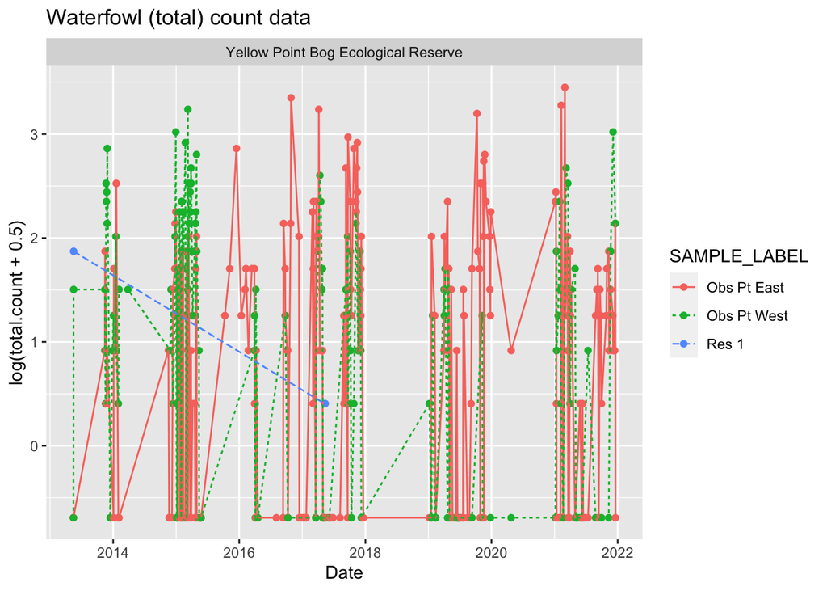

Figure 1: Summary plot of the data. Data is plotted on the logarithmic scale because of the wide range of values. Because of potential zeros in the data, 0.5 was added to all points only for plotting purposes.

Notice that there may be evidence of station effect, where for example, the number of birds at certain stations are generally higher than at the other stations because of local station-specific conditions (e.g. better habitat).

Next the maximum count in each month in each station (but only November, December, January, and February) is found. The maximum counts are:

```
                        STUDY_AREA_NAME SAMPLE_LABEL Year Month max.count
1   Yellow Point Bog Ecological Reserve  Obs Pt East 2013     5         0
2   Yellow Point Bog Ecological Reserve  Obs Pt East 2013    11         6
3   Yellow Point Bog Ecological Reserve  Obs Pt East 2014     1        12
4   Yellow Point Bog Ecological Reserve  Obs Pt East 2014     2         0
5   Yellow Point Bog Ecological Reserve  Obs Pt East 2014    11         2
6   Yellow Point Bog Ecological Reserve  Obs Pt East 2014    12         9
7   Yellow Point Bog Ecological Reserve  Obs Pt East 2015     1         6
8   Yellow Point Bog Ecological Reserve  Obs Pt East 2015     2         6
9   Yellow Point Bog Ecological Reserve  Obs Pt East 2015     3         7
10  Yellow Point Bog Ecological Reserve  Obs Pt East 2015     4         7
11  Yellow Point Bog Ecological Reserve  Obs Pt East 2015     5         0
12  Yellow Point Bog Ecological Reserve  Obs Pt East 2015    10         3
13  Yellow Point Bog Ecological Reserve  Obs Pt East 2015    11         5
14  Yellow Point Bog Ecological Reserve  Obs Pt East 2015    12        17
```

[output cut: 90 more lines]

When the maximum counts are restricted to November, December, January, and February, the data are now:

```
                        STUDY_AREA_NAME SAMPLE_LABEL Year Month max.count
2   Yellow Point Bog Ecological Reserve  Obs Pt East 2013    11         6
3   Yellow Point Bog Ecological Reserve  Obs Pt East 2014     1        12
4   Yellow Point Bog Ecological Reserve  Obs Pt East 2014     2         0
5   Yellow Point Bog Ecological Reserve  Obs Pt East 2014    11         2
6   Yellow Point Bog Ecological Reserve  Obs Pt East 2014    12         9
7   Yellow Point Bog Ecological Reserve  Obs Pt East 2015     1         6
8   Yellow Point Bog Ecological Reserve  Obs Pt East 2015     2         6
13  Yellow Point Bog Ecological Reserve  Obs Pt East 2015    11         5
14  Yellow Point Bog Ecological Reserve  Obs Pt East 2015    12        17
15  Yellow Point Bog Ecological Reserve  Obs Pt East 2016     1         3
16  Yellow Point Bog Ecological Reserve  Obs Pt East 2016     2         5
22  Yellow Point Bog Ecological Reserve  Obs Pt East 2016    12         7
23  Yellow Point Bog Ecological Reserve  Obs Pt East 2017     1         0
24  Yellow Point Bog Ecological Reserve  Obs Pt East 2017     2         9
```

[output cut: 28 more lines]

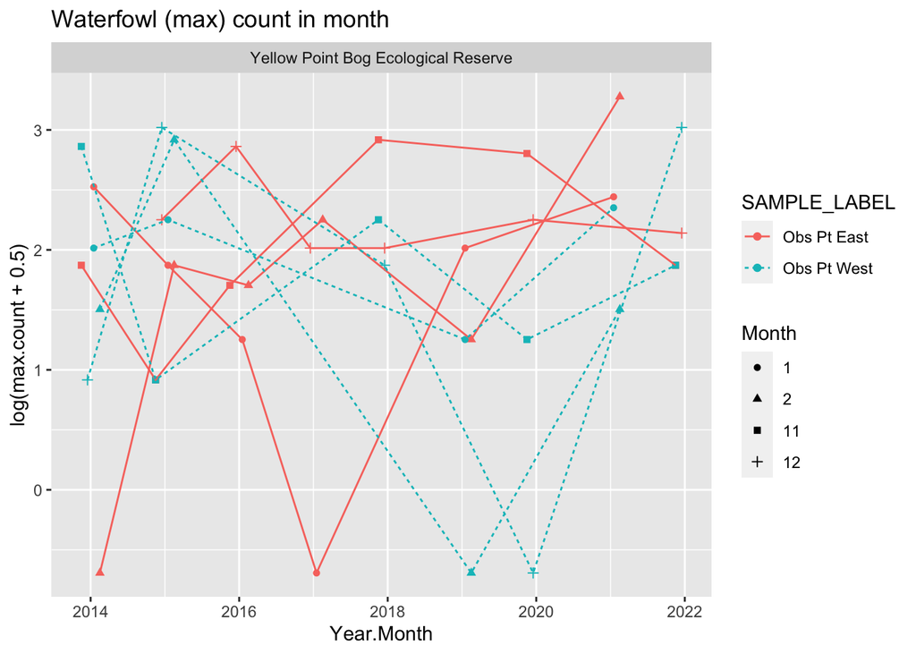

Figure 2: Plot of the maximum count in each station in November through February. Data is plotted on the logarithmic scale because of the wide range of values. Because of potential zeros in the data, 0.5 was added to all points only for plotting purposes.

Again there may be evidence of a consistent station effect and/or a consistent month effect.

Because this is count data, so a linear mixed model is fit to the logarithm of the maximum call in each month at each transect in each year. The model is:
$$log(MaxCount) = \mathit{Year} + \mathit{MonthF}+ \mathit{StationF(R)} +\mathit{YearF(R)}$$
where

- $log(MaxCount)$ is logarithm of the maximum count at that station in that month in that year;
- $\mathit{StationF}$ represents the station effect;
- $\mathit{YearF}$ represents the year-specific effects (process error), and
- $\mathit{Year}$ represents the calendar year trend over time.

The $\mathit{StationF}$ term allows for the fact that station-specific conditions may tend to affect the counts on this station consistently over time. The $\mathit{YearF}$ term represent the year-specific effects (process error) caused by environmental factors (e.g., a warmer than normal year may elicit more visits from waterfowl).

This model implicitly assumes that the trend in Nov, Dec, Jan and February are the same but with a different intercept (i.e. parallel lines on the logarithmic scale).

Model fit on the logarithmic scale assume that effects are multiplicative over time, so that the when the actual fit is done on the logarithmic scale, the trends are linear. For example, a trend may assume that there is constant 5% change over time rather than a fixed 1 unit change per year. Some caution is needed if any of the values are 0 as log(0) is not defined. In these cases, a small constant (typically ½ of the smallest positive value in the dataset) is added to all values before the analysis proceeds.

This model is fit using the *lmer()* function in the lmerTest package (Kuznetsova, et al. 2016)

```
boundary (singular) fit: see help('isSingular')
```

```
Type III Analysis of Variance Table with Kenward-Roger's method
       Sum Sq Mean Sq NumDF  DenDF F value Pr(>F)
Year   0.0843  0.0843     1  3.949  0.0832 0.7875
MonthF 1.6104  0.5368     3 32.780  0.5298 0.6650
```

```
Linear mixed model fit by REML. t-tests use Satterthwaite's method [
lmerModLmerTest]
Formula: log(max.count + 0.5) ~ Year + MonthF + (1 | SAMPLE_LABELF) +
    (1 | YearF)
   Data: count.max

REML criterion at convergence: 122.7

Scaled residuals:
    Min      1Q  Median      3Q     Max
-2.4276 -0.3580  0.1077  0.5211  1.5072

Random effects:
 Groups        Name        Variance  Std.Dev.
 YearF         (Intercept) 9.755e-02 3.123e-01
 SAMPLE_LABELF (Intercept) 3.024e-10 1.739e-05
 Residual                  1.013e+00 1.006e+00
Number of obs: 42, groups:  YearF, 7; SAMPLE_LABELF, 2

Fixed effects:
             Estimate Std. Error        df t value Pr(>|t|)
(Intercept) -42.42336  149.84171   5.20729  -0.283    0.788
Year          0.02189    0.07429   5.20403   0.295    0.780
MonthF2      -0.23873    0.45009  33.42352  -0.530    0.599
MonthF11      0.23318    0.44591  35.59129   0.523    0.604
MonthF12      0.26748    0.44208  34.35511   0.605    0.549

Correlation of Fixed Effects:
         (Intr) Year   MnthF2 MntF11
Year     -1.000
MonthF2  -0.002  0.000
MonthF11 -0.066  0.065  0.505
MonthF12 -0.030  0.029  0.509  0.529
optimizer (nloptwrap) convergence code: 0 (OK)
boundary (singular) fit: see help('isSingular')
```

```
 Groups        Name        Std.Dev.
 YearF         (Intercept) 3.1233e-01
 SAMPLE_LABELF (Intercept) 1.7389e-05
 Residual                  1.0064e+00
```

[output not shown]

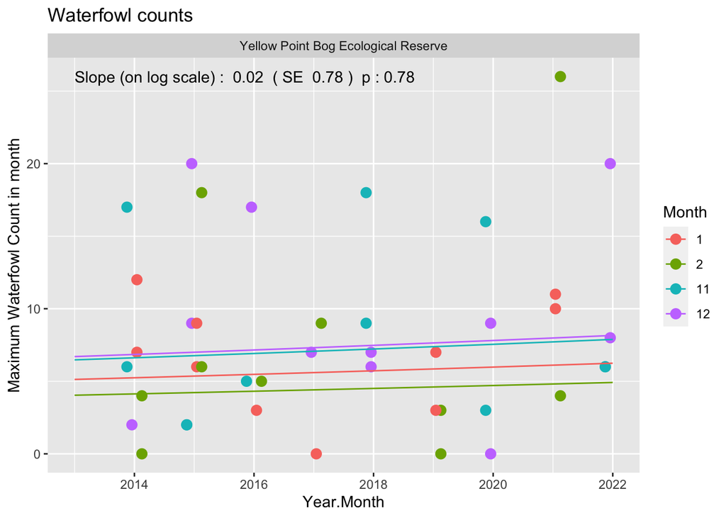

Figure 3: Summary plot of the trend in maximum birds counts. Because the model was fit on the logarithmic scale, the fitted trend line is not a straight line but curved.

The reported common slope is on the logarithmic scale. This corresponds to an approximate exp(0.022)= 1.02x multiplicative change/year, i.e. the mean maximum count in year $t+1$ is about 1.02x the mean maximum count in year $t$. Because the analysis is done on the logarithmic scale, the fitted trend line will look non-linear on the original (non-transformed) scale.

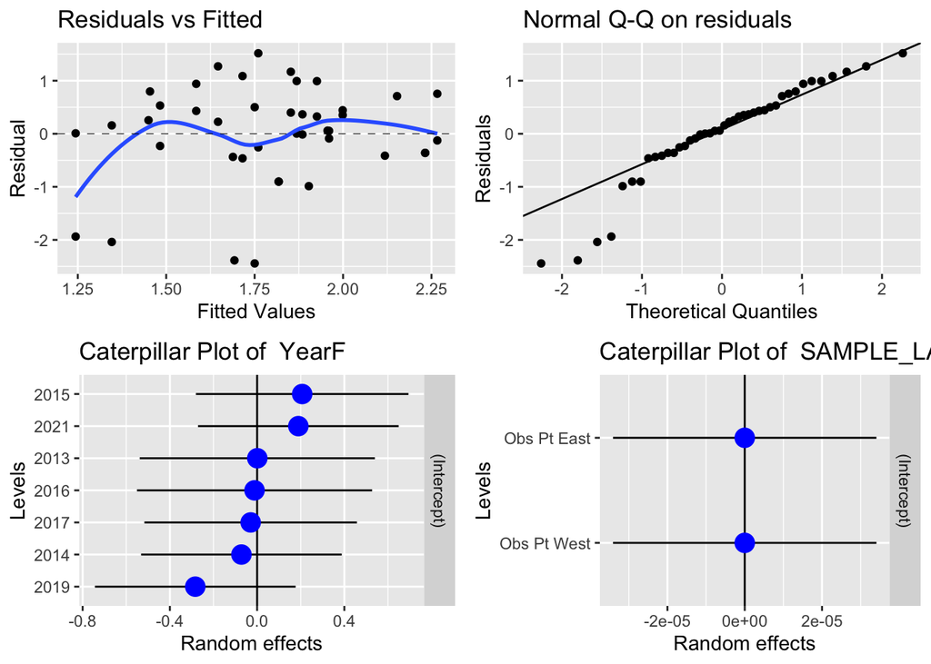

Figure 4: Model fit diagnostic plots from trend in maximum count

Whenever an analysis of a trend over time is conducted, the analysis should test and adjust for autocorrelation. Autocorrelation usually isn’t a problem (and likely cannot be detected) unless you have 10+ years of data. The test for autocorrelation commonly used is the Durbin-Watson test and we find (p = 0.434 for the test of no autocorrelation.

The analysis of the median count per month would follow the same steps as shown above and the R code is easy to modify. Similarly, this analysis was conducted at the total count level (over all species) but could be done for individual species. One potential problem is that in some cases, species information is only recorded at the Genus or higher level. In these case, this data will have to discarded when the analysis is done at the species level, but then you are making an implicit assumption that recording at the Genus level happens at random and is unrelated to the response. If this assumption is violated (e.g. perhaps when there are larger number of birds, it is too difficult to record at the individual species level) then this is not occurring at random and some effort must be made to “split” the genus level information among the species.

Trends over time could also occur in the diversity of the birds. In theory, standard diversity measures could be used and tracked over time, but these have a very strong assumption that all species are equally detectable by the observer. This is unlikely to be true. Secondly, the actual counts are quite small, and diversity measures that rely on actual counts (e.g. Simpson’s diversity) will not perform well. For this reason, I do not recommend an analysis on the diversity of the observations.

# 4 Power analysis

A power/sample size analysis was conducted to determine the number of years of sampling needed to detect changes over time. The steps in the power/sample size analysis are:

- Compute a single number summarizing the response at this site in each year. The mean number of calls is currently recorded by transect and the average over the transects will be computed.
- Analyze the log(mean response) using a simple linear regression. This will give an estimate of the combined year-specific and sampling variation around regression line (overall sd).
- Use the overall SD to estimate power and sample size requirements.

Here are the overall means for each year for each response:

```
 [1] 11  1  2 11 12  1  2 11 12  1  2 12  1  2 11 12  1  2 11 12  1  2 11 12 11
[26] 12  1  2 11 12  1  2 11 12  1  2 11 12  1  2 11 12
```

```
                      STUDY_AREA_NAME Year  mean.max Mean.response
1 Yellow Point Bog Ecological Reserve 2013  8.333333      8.333333
2 Yellow Point Bog Ecological Reserve 2014  7.000000      7.000000
3 Yellow Point Bog Ecological Reserve 2015 10.166667     10.166667
4 Yellow Point Bog Ecological Reserve 2016  5.000000      5.000000
5 Yellow Point Bog Ecological Reserve 2017  8.166667      8.166667
6 Yellow Point Bog Ecological Reserve 2019  5.125000      5.125000
7 Yellow Point Bog Ecological Reserve 2021 11.375000     11.375000
          Response
1 Mean max N/D/J/F
2 Mean max N/D/J/F
3 Mean max N/D/J/F
4 Mean max N/D/J/F
5 Mean max N/D/J/F
6 Mean max N/D/J/F
7 Mean max N/D/J/F
```

The above data needs to be checked if there are any suspicious values.

We use the *lm()* function to fit linear regression over time on the log(scale) and obtain the combined year-specific effect (process error) plus sampling variation standard deviation (Table 1).

Table 1: Estimated residual (process + sampling) standard deviation

| Response | Process + sampling SD |
| --- | --- |
| Mean max N/D/J/F | 0.2556 |

This is then used to estimate the power to detect various proportional changes over time (Figure 5).

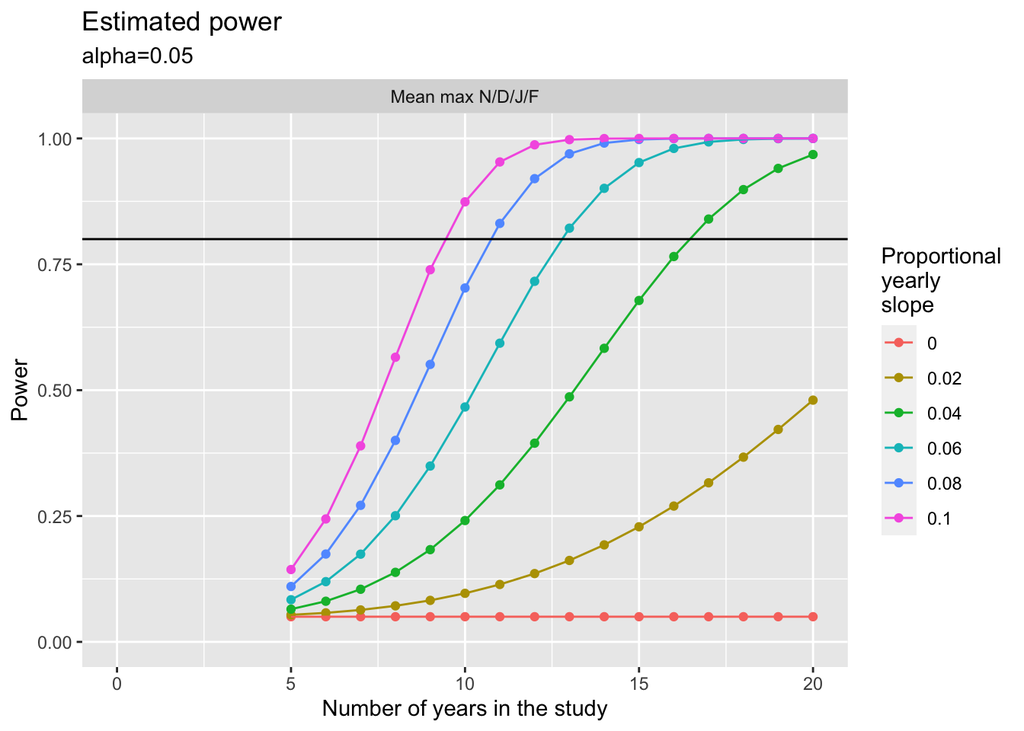

Figure 5: Estimated power to detect proportional changes over time

The proportional yearly slope indicates the effect size of interest. For example, a value of .02 would indicated a 2% change/year in the mean response.

In cases of high variability, the power is uniformly low to detect the yearly proportion change over time. In cases of low variability power is uniformly very high to detect the yearly proportion change over time.

# 5 Summary

The protocol assumes that the observation points allow the observer to see all the waterfowl on the wetland between them so differential coverage over time may not be a problem.

# 6 References

Kuznetsova A, Brockhoff PB, Christensen RHB (2017). lmerTest Package: Tests in Linear Mixed Effects Models. Journal of Statistical Software, 82, 1-26. doi:10.18637/jss.v082.i13

R Core Team (2022). R: A language and environment for statistical computing. R Foundation for Statistical Computing, Vienna, Austria. https://www.R-project.org/.